# Restricted and Threatened Plant Species in Kenya

A Comprehensive Botanical Legal and Conservation Reference

Kwiz Computing

05 April 2026

# Executive Summary

Kenya harbours over **7,000 plant species**, including approximately 1,847 endemics, making it one of Africa’s most botanically significant nations. Despite this richness, plant species remain substantially under-regulated compared to fauna in Kenya’s legal framework.

Kenya’s plant protection regime is distributed across multiple statutes – the Forest Conservation and Management Act 2016, the Environmental Management and Co-ordination Act 1999, the Seeds and Plant Varieties Act, the Plant Protection Act, the Biosafety Act 2009, and CITES implementation regulations – administered by distinct institutions including KFS, KEPHIS, NEMA, and NBA. This fragmentation creates significant gaps: the majority of Kenya’s IUCN-threatened tree species have no specific domestic gazette protection, and court enforcement of CITES plant provisions has demonstrated documented failures.

# 1 Legal Framework for Plant Protection

Kenya’s plant protection laws span forestry, phytosanitary, environmental, and international trade legislation. Unlike wildlife – governed primarily by a single comprehensive Act (WCMA 2013) – plant species fall under multiple, often overlapping statutes with no single coordinating instrument.

## 1.1 Forest Conservation and Management Act, 2016 (FCMA)

The **FCMA (No. 34 of 2016)** governs Kenya’s public forests, covering approximately 1.68 million hectares of gazetted forest. **Section 40** empowers the Cabinet Secretary to gazette any tree species as **protected** on the advice of the Kenya Forestry Research Institute (KEFRI).

Key provisions for plant species:

- **Section 40 – Protected Trees:** The Cabinet Secretary may, by Gazette notice on advice of KEFRI, declare any tree species as protected. Harvesting, transporting, or trading in protected tree species without KFS authorisation is an offence.
- **Section 64 – Forest Products:** Regulates the harvesting, transportation, and trade of all forest products (timber, non-timber forest products, medicinal plants).
- **Section 66 – Offences:** Illegal harvesting of forest products carries fines up to **KES 2 million or imprisonment of up to 5 years**, or both.

Notable applications: East African sandalwood (*Osyris lanceolata*) has been subjected to export bans due to massive illegal trafficking. *Prunus africana* (African cherry), used in prostate medication manufacturing, is regulated under both the FCMA and CITES Appendix II.

Full text: [Kenya Law – FCMA 2016](https://new.kenyalaw.org/akn/ke/act/2016/34/eng@2022-12-31)

**Implementation Gap** – The FCMA s.40 protection mechanism is entirely reactive: it requires a Cabinet Secretary Gazette order on KEFRI advice, with **no statutory programme obliging KFS to systematically assess and gazette threatened species**. BGCI has documented that Kenya has **over 120 tree species** meeting IUCN threatened criteria, including 34 endemics, yet most receive no specific gazette protection. A 2020 BGCI/KFS planning workshop resulted in formation of the Kenya Threatened Trees Consortium – but this body has no binding legal authority. ([BGCI – Planning Conservation Action for Kenya’s Threatened Trees, 2020](https://www.bgci.org/wp/wp-content/uploads/2021/08/Planning-Conservation-Action-for-Kenyas-threatened-tree-species-1.pdf))

## 1.2 Environmental Management and Co-ordination Act, 1999 (EMCA)

The **EMCA (No. 8 of 1999)** is Kenya’s framework environmental law. Its provisions affecting plant species include:

- **Section 55:** Prohibits introduction of any plant (alien or indigenous) into rivers, lakes, or the sea without authorisation – the primary legal tool against invasive alien plant species introduction.
- **Part V – Conservation of Biological Diversity:** Requires in-situ and ex-situ conservation measures for all biological diversity, including plants.
- **Biodiversity Regulations 2023:** Require NEMA to maintain an inventory of all threatened and endangered species (including plants) and authorise NEMA to impose bans or restrictions on access.

Full text: [Kenya Law – EMCA 1999](https://new.kenyalaw.org/akn/ke/act/1999/8/eng@2022-12-31)

## 1.3 Seeds and Plant Varieties Act (Cap. 326)

The **Seeds and Plant Varieties Act** regulates the importation, certification, and trade of seeds and plant varieties. It establishes:

- **Plant Breeders’ Rights:** Protection of new plant varieties developed through breeding.
- **Seed Certification:** All seed sold commercially must meet quality standards enforced by KEPHIS.
- **Import/Export Controls:** Seeds and planting material require phytosanitary certification before import or export.

Administered by **KEPHIS** (kephis.go.ke).

## 1.4 Plant Protection Act (Cap. 324)

The **Plant Protection Act** empowers the Cabinet Secretary to prohibit or restrict importation of any plants and associated materials – providing the primary legal tool for preventing entry of invasive plant species and plant pests into Kenya. Key powers include:

- **Import Prohibition Orders:** Authority to ban importation of any plant species, soil, or plant material that may introduce pests or diseases.
- **Quarantine:** Authority to declare quarantine zones and restrict movement of plants within Kenya.
- **Inspection and Destruction:** Powers to inspect, seize, and destroy infected or prohibited plant material.

Administered by **KEPHIS**. Full text: [Kenya Law – Plant Protection Act](https://new.kenyalaw.org/akn/ke/act/1937/24/eng@2022-12-31)

## 1.5 CITES Plant Provisions

Kenya ratified CITES in 1978. The convention regulates international trade in numerous plant species, with enforcement in Kenya through:

- **L.N. 241/2017** – Wildlife Conservation and Management (Implementation of Treaties) Regulations
- **L.N. 242/2017** – Wildlife Conservation and Management (Protection of Endangered and Threatened Ecosystems, Habitats and Species) Regulations

CITES plant listings relevant to Kenya include:

| Appendix | Trade Restriction | Key Kenya Plant Species |
| --- | --- | --- |
| **I** | Commercial trade prohibited | Rare orchids, certain cycads |
| **II** | Trade permitted with export permit | *Prunus africana*, all *Aloe* spp., all Orchidaceae, all Euphorbia (succulent spp.), all Cactaceae |
| **III** | Import requires certificate of origin | Various |

**KWS** is the designated CITES Management Authority for plants.

**Implementation Gap** – A 2024 peer-reviewed study documented that in 2014, Kenya seized 8,069 rosewood logs (CITES-regulated, Appendix II/III) illegally exported from Madagascar. Despite multiple trials and appeals, courts ordered the logs returned to shippers. CITES notifications arrived after final determinations. The case revealed that **Kenyan courts do not adequately understand CITES Appendix listings for plants**. ([Kilonzo, Heinen & Byakagaba, *Diversity* 16(3):183, 2024](https://www.mdpi.com/1424-2818/16/3/183))

## 1.6 Biosafety Act, 2009

The **Biosafety Act (No. 2 of 2009)** governs all activities involving **genetically modified organisms (GMOs)**, including GM plant varieties. All import, export, contained use, environmental release, and commercialisation of GM plants requires prior approval from the **National Biosafety Authority** (NBA). As of 2024, the NBA has approved 58 GMO projects including commercial cultivation of Bt cotton and Bt corn. Unauthorised handling of GMOs carries fines up to **KES 20 million or up to 10 years imprisonment**.

Full text: [Kenya Law – Biosafety Act 2009](https://new.kenyalaw.org/akn/ke/act/2009/2/eng@2023-12-11)

# 2 Regulatory Institutions for Plant Protection

The following institutions have mandates directly relevant to plant species protection and regulation in Kenya.

Table 1. Institutions with Plant Species Regulatory Mandates in Kenya

| Abbrev. | Institution | Ministry | Est. | Mandate |
| --- | --- | --- | --- | --- |
| DVS | Directorate of Veterinary Services | Ministry of Agriculture, Livestock, Fisheries and Co-operatives | NA | Regulate import/export of animals and animal products; enforce animal health standards; participate in biosafety authority; control diseases including zoonoses affecting wildlife |
| KFS | Kenya Forest Service | Ministry of Environment, Climate Change and Forestry | 2007 | Manage all public forests; regulate commercial exploitation of forest resources; conserve forest biodiversity; enforce forest laws; issue permits for forest product trade/export |
| KEFRI | Kenya Forestry Research Institute | Ministry of Environment, Climate Change and Forestry | 1986 | Conduct and coordinate forestry research; advise KFS and Cabinet Secretary on protected tree species; maintain forest germplasm bank; develop guidelines for sustainable forest management |
| KEPHIS | Kenya Plant Health Inspectorate Service | Ministry of Agriculture, Livestock, Fisheries and Co-operatives | 1997 | Safeguard the quality and health of plants and plant products; prevent introduction and spread of plant pests and diseases; regulate importation and exportation of plants and seeds; administer Seeds a… |
| NBA | National Biosafety Authority | Ministry of Agriculture, Livestock, Fisheries and Co-operatives | 2009 | Exercise general supervision and control over transfer, handling and use of GMOs; issue approvals for contained use, environmental release, import, export and transit of GMOs; advise government on bio… |
| NEMA | National Environment Management Authority | Ministry of Environment, Climate Change and Forestry | 2002 | Exercise general supervision and co-ordination over environmental management; set environmental standards; review Environmental Impact Assessments; regulate access to genetic resources; administer bio… |
| NETFUND | National Environment Trust Fund | Ministry of Environment, Climate Change and Forestry | 2000 | Finance environmental conservation programmes; grant funding for biodiversity conservation; support NEMA and KFS programmes |

### 2.0.1 Institutional Roles Summary

- **Kenya Forest Service (KFS):** Manages public forests; enforces FCMA 2016; administers protected tree gazette orders; licences forest product harvesting and trade.
- **KEPHIS (Kenya Plant Health Inspectorate Service):** Enforces Plant Protection Act and Seeds and Plant Varieties Act; phytosanitary inspection of all plant imports/exports; pest risk analysis; seed certification.
- **NEMA (National Environment Management Authority):** Framework environmental regulator; enforces EMCA 1999; maintains biodiversity inventory mandate (Biodiversity Regulations 2023); regulates introduction of alien species.
- **NBA (National Biosafety Authority):** Regulates all genetically modified plant organisms under the Biosafety Act 2009; approves GM crop field trials and commercial release.

# 3 Comprehensive Plant Species Listing

The master listing covers **125 plant species** that are subject to some form of restriction under Kenyan law. These include IUCN-threatened trees, CITES-listed species, and invasive/prohibited plants.

## 3.1 Overview: Plant Species by IUCN Status

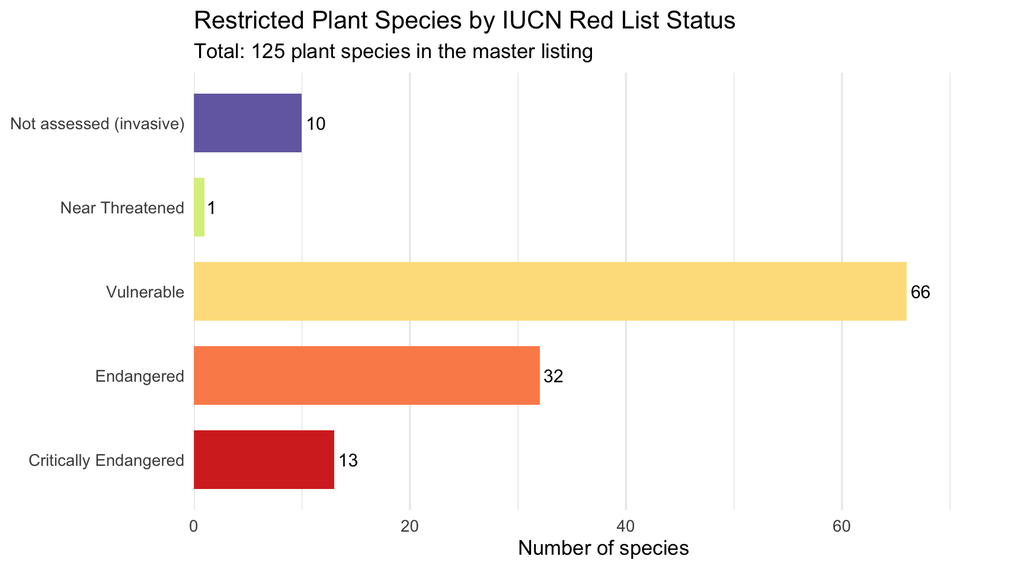

Plant species count by IUCN Red List status.

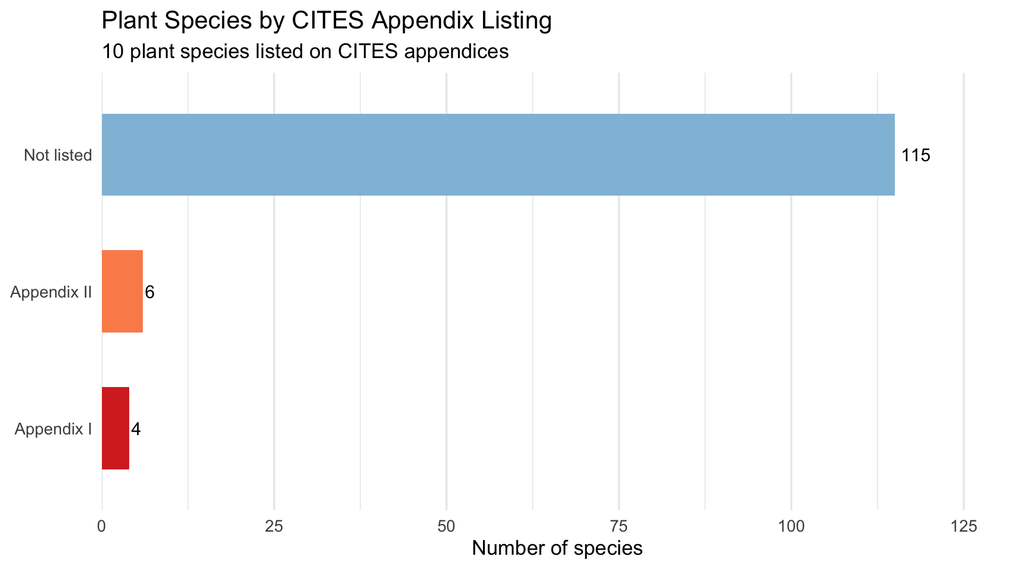

Plant species by CITES appendix listing.

## 3.2 Master Plant Species Table

Table 2. Complete Listing of Restricted/Protected Plant Species in Kenya

[output not shown]

[output cut: 95 more lines]

## 3.3 Threatened Trees

Kenya has over 120 tree species meeting IUCN threatened criteria (Critically Endangered, Endangered, or Vulnerable), including approximately 34 endemics. The Taita Hills alone contain 19 threatened tree species in an area of roughly 20 x 20 km, representing one of the world’s highest endemic plant concentrations.

Table 3. Threatened Plant Species in Kenya (CR, EN, VU) – 111 species

[output not shown]

[output cut: 81 more lines]

## 3.4 CITES-Listed Plants

CITES regulates international trade in a substantial number of plant genera and species. All *Aloe* species, all Orchidaceae, succulent Euphorbia species, and all Cactaceae are listed on Appendix II. *Prunus africana* – one of Kenya’s most commercially significant plant species – is listed on CITES Appendix II due to heavy exploitation for pharmaceutical bark extraction.

Table 4. CITES-Listed Plant Species in Kenya – 10 species

[output not shown]

## 3.5 Invasive and Prohibited Plants

Kenya has documented several established invasive alien plant species. Introduction of alien plant species into water bodies is prohibited under EMCA Section 55; plant import prohibitions are administered by KEPHIS under the Plant Protection Act. Notable invasive plants in Kenya include *Prosopis juliflora* (mathenge), *Lantana camara*, and various water hyacinth species.

Table 5. Invasive and Prohibited Plant Species in Kenya – 8 species

| Common Name | Scientific Name | Group | Kenya Status | Restriction Type | Notes | Sources |
| --- | --- | --- | --- | --- | --- | --- |
| Eucalyptus (invasive populations) | *Eucalyptus spp.* | Magnoliopsida | Regulated; invasive in riparian zones | Regulated introduction; invasive alien species | Widely cultivated but ecologically invasive in riparian zones; high water consumption and allelopathy. NEMA restriction on planting near wetlands. | [EMCA 1999 (Kenya Law)](https://new.kenyalaw.org/akn/ke/act/1999/8/eng@2022-12-31) \| [IUCN](https://www.iucnredlist.org/search?query=Eucalyptus%20spp.) |
| Lantana | *Lantana camara* | Magnoliopsida | Introduction restricted; declared invasive | Restricted | Widespread invasive in mid-altitude zones. Displaces native vegetation; creates tsetse habitat. | [Plant Protection Act Cap.324](https://new.kenyalaw.org/akn/ke/act/1937/24/eng@2022-12-31) \| [IUCN](https://www.iucnredlist.org/search?query=Lantana%20camara) |
| Mexican marigold | *Tagetes minuta* | Magnoliopsida | Prohibited introduction; invasive weed | Prohibited introduction; invasive alien species | Invasive annual weed widespread in highland Kenya; allelopathic effects suppress native plants. | [EMCA 1999 (Kenya Law)](https://new.kenyalaw.org/akn/ke/act/1999/8/eng@2022-12-31) \| [IUCN](https://www.iucnredlist.org/search?query=Tagetes%20minuta) |
| Morning glory | *Ipomoea spp.* | Magnoliopsida | Prohibited introduction; invasive weed | Prohibited introduction; invasive alien species | Several Ipomoea species invasive in croplands and rangelands; smothers native vegetation. | [EMCA 1999 (Kenya Law)](https://new.kenyalaw.org/akn/ke/act/1999/8/eng@2022-12-31) \| [IUCN](https://www.iucnredlist.org/search?query=Ipomoea%20spp.) |
| Silverleaf nightshade | *Solanum elaeagnifolium* | Magnoliopsida | Introduction prohibited | Prohibited introduction | Crop pest and invasive plant. On Kenya phytosanitary prohibited import list. | [Plant Protection Act Cap.324](https://new.kenyalaw.org/akn/ke/act/1937/24/eng@2022-12-31) \| [IUCN](https://www.iucnredlist.org/search?query=Solanum%20elaeagnifolium) |
| Water fern (Kariba weed) | *Salvinia molesta* | Polypodiopsida | Introduction prohibited | Prohibited introduction | Covers water surfaces; disrupts fisheries and water supply. | [EMCA 1999 s.55 (Kenya Law)](https://new.kenyalaw.org/akn/ke/act/1999/8/eng@2022-12-31) \| [IUCN](https://www.iucnredlist.org/search?query=Salvinia%20molesta) |
| Water hyacinth | *Eichhornia crassipes* | Magnoliopsida | Introduction prohibited; eradication programmes active | Prohibited introduction; active control | Introduced 1989. Covers large areas of Lake Victoria. Biocontrol (weevils) deployed. | [EMCA 1999 s.55 (Kenya Law)](https://new.kenyalaw.org/akn/ke/act/1999/8/eng@2022-12-31) \| [IUCN](https://www.iucnredlist.org/search?query=Eichhornia%20crassipes) |
| Wild garlic | *Allium vineale* | Magnoliopsida | Prohibited introduction; invasive weed | Prohibited introduction; invasive alien species | Invasive weed that contaminates wheat and taints dairy products. | [Plant Protection Act Cap.324](https://new.kenyalaw.org/akn/ke/act/1937/24/eng@2022-12-31) \| [IUCN](https://www.iucnredlist.org/search?query=Allium%20vineale) |

## 3.6 GBIF Backbone Taxonomy

The GBIF Backbone Taxonomy resolves scientific names to the current authoritative taxonomy, fetches English vernacular names and known synonyms, and links each species to its GBIF species page and IUCN Red List assessment. Species were resolved using `rgbif::name_backbone_checklist()` (batch mode) with individual fallback queries via `rgbif::name_backbone()`. Vernacular names and synonyms were fetched from GBIF’s `name_usage()` API endpoints.

**Resolution summary:** 125 of 125 plant species matched to a GBIF usage key across **50 families** (2 aquatic species).

**Note:** Click any scientific name to open the GBIF species page. Click the IUCN or CITES links to check current global conservation and trade status. GBIF vernacular names supplement (but do not replace) the legal common names in the master listing.

Table 7. GBIF-Resolved Plant Species by Kenya Legal Classification

| Kenya Classification | Species Count |
| --- | --- |
| Protected / Regulated | 113 |
| Prohibited | 9 |
| Restricted | 3 |

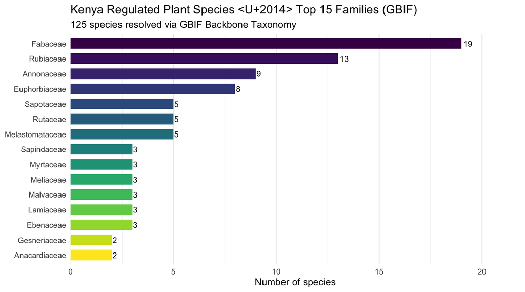

GBIF-resolved plant species by family (top 15 families).

| # | Scientific Name | Common Name | Family | GBIF Records (KE) | Kenya Status | Aquatic | Synonyms | IUCN | CITES |
| --- | --- | --- | --- | --- | --- | --- | --- | --- | --- |
| 1 | [*Pontederia crassipes*](https://www.gbif.org/species/2765940) | Common water hyacinth, Kachuripana, Water hyacinth, common water hyacinth, common water-hyacinth, floating water hyacinth, floating waterhyacinth, lilac-devil, water hyacinth, water-hyacinth, Water-hy… | Pontederiaceae | [31](https://www.gbif.org/occurrence/search?taxon_key=2765940&country=KE) | Prohibited | Freshwater |  | [IUCN ↗](https://www.iucnredlist.org/search?query=Pontederia%20crassipes) | [CITES ↗](https://checklist.cites.org/#/en/search/output_layout=alphabetical&scientific_name=Pontederia%20crassipes) |
| 2 | [*Salvinia molesta*](https://www.gbif.org/species/5274863) | African payal, Giant salvinia, Kariba weed, Water fern, African payal, African pyle, Aquarium watermoss, Giant water fern, Velvet weed, Kariba weed, Salvinia moss, aquarium watermoss, giant salvinia, … | Salviniaceae | [26](https://www.gbif.org/occurrence/search?taxon_key=5274863&country=KE) | Prohibited | Freshwater | Salvinia adnata | [IUCN ↗](https://www.iucnredlist.org/search?query=Salvinia%20molesta) | [CITES ↗](https://checklist.cites.org/#/en/search/output_layout=alphabetical&scientific_name=Salvinia%20molesta) |
| 3 | [*Prosopis juliflora*](https://www.gbif.org/species/5358460) | Mesquite, Prosopis, Mesquite, Algaroba bean, Mexican thorn, Ironwood, algarroba-bean, ironwood, mesquite | Fabaceae | [498](https://www.gbif.org/occurrence/search?taxon_key=5358460&country=KE) | Restricted |  | Acacia juliflora, Algarobia juliflora, Entada juliflora, Mimosa furcata, Mimosa juliflo… | [IUCN ↗](https://www.iucnredlist.org/search?query=Prosopis%20juliflora) | [CITES ↗](https://checklist.cites.org/#/en/search/output_layout=alphabetical&scientific_name=Prosopis%20juliflora) |
| 4 | [*Lantana camara*](https://www.gbif.org/species/2925303) | Black Sage, Lantana, Largeleaf Lantana, Sage, Scrubby Cup, Scrubby Tree, Statia Sage, Wild Lantana, Yellow Sage, common lantana, kamara lantana, largeleaf lantana, wild sage, Common Lantana, Wild Sage… | Verbenaceae | [1,321](https://www.gbif.org/occurrence/search?taxon_key=2925303&country=KE) | Restricted |  | Camara vulgaris, Lantana camara camara, Lantana camara parvifolia, Lantana coccinea, La… | [IUCN ↗](https://www.iucnredlist.org/search?query=Lantana%20camara) | [CITES ↗](https://checklist.cites.org/#/en/search/output_layout=alphabetical&scientific_name=Lantana%20camara) |
| 5 | [*Opuntia stricta*](https://www.gbif.org/species/5384075) | Araluen pear, Common pest pear, Prickly pear, Erect Pricklypear, Erect Pricklypear, Erect prickly pear, Prickle, Sour Prickle, erect prickly-pear | Cactaceae | [583](https://www.gbif.org/occurrence/search?taxon_key=5384075&country=KE) | Restricted |  | Cactus opuntia inermis, Cactus strictus, Consolea bahamana, Opuntia airampo, Opuntia ba… | [IUCN ↗](https://www.iucnredlist.org/search?query=Opuntia%20stricta) | [CITES ↗](https://checklist.cites.org/#/en/search/output_layout=alphabetical&scientific_name=Opuntia%20stricta) |
| 6 | [*Solanum elaeagnifolium*](https://www.gbif.org/species/2929892) | Bull-nettle, Silverleaf nightshade, White Nightshade, bull-nettle, prairie-berry, silverleaf bitter-apple, silverleaf nightshade, silverleaf-nettle, tomato weed, tomato-weed, white horse-nettle, white… | Solanaceae | [0](https://www.gbif.org/occurrence/search?taxon_key=2929892&country=KE) | Prohibited |  | Solanum dealbatum, Solanum elaeagnifolium albiflorum, Solanum elaeagnifolium benkei, So… | [IUCN ↗](https://www.iucnredlist.org/search?query=Solanum%20elaeagnifolium) | [CITES ↗](https://checklist.cites.org/#/en/search/output_layout=alphabetical&scientific_name=Solanum%20elaeagnifolium) |
| 7 | [*Osyris lanceolata*](https://www.gbif.org/species/7473922) | East African sandalwood | Santalaceae | [54](https://www.gbif.org/occurrence/search?taxon_key=7473922&country=KE) | Prohibited |  | Osyris arborea, Osyris arborea puberula, Osyris arborea rotundifolia, Osyris arborea st… | [IUCN ↗](https://www.iucnredlist.org/search?query=Osyris%20lanceolata) | [CITES ↗](https://checklist.cites.org/#/en/search/output_layout=alphabetical&scientific_name=Osyris%20lanceolata) |
| 8 | [*Prunus africana*](https://www.gbif.org/species/3022853) | African Almond, African cherry, Red Stinkwood, pygeum, African Cherry | Rosaceae | [171](https://www.gbif.org/occurrence/search?taxon_key=3022853&country=KE) | Protected / Regulated |  | Laurocerasus africana, Laurocerasus crassifolia, Prunus crassifolia, Pygeum africanum, … | [IUCN ↗](https://www.iucnredlist.org/search?query=Prunus%20africana) | [CITES ↗](https://checklist.cites.org/#/en/search/output_layout=alphabetical&scientific_name=Prunus%20africana) |
| 9 | [*Aloe*](https://www.gbif.org/species/2770879) | Aloes, aloe, aloes | Asphodelaceae | [1,100](https://www.gbif.org/occurrence/search?taxon_key=2770879&country=KE) | Protected / Regulated |  | Agriodendron, Aloe qaharensis, Aloinella, Aloe, Atevala, Busipho, Chamaealoe, Chortolir… | [IUCN ↗](https://www.iucnredlist.org/search?query=Aloe) |  |
| 10 | [*Streptocarpus ionanthus*](https://www.gbif.org/species/6365236) | African-violet, Usambara-violet | Gesneriaceae | [0](https://www.gbif.org/occurrence/search?taxon_key=6365236&country=KE) | Prohibited |  |  | [IUCN ↗](https://www.iucnredlist.org/search?query=Streptocarpus%20ionanthus) | [CITES ↗](https://checklist.cites.org/#/en/search/output_layout=alphabetical&scientific_name=Streptocarpus%20ionanthus) |
| 11 | [*Streptocarpus teitensis*](https://www.gbif.org/species/3819564) | Taita Hills violet | Gesneriaceae | [13](https://www.gbif.org/occurrence/search?taxon_key=3819564&country=KE) | Protected / Regulated |  |  | [IUCN ↗](https://www.iucnredlist.org/search?query=Streptocarpus%20teitensis) | [CITES ↗](https://checklist.cites.org/#/en/search/output_layout=alphabetical&scientific_name=Streptocarpus%20teitensis) |
| 12 | [*Encephalartos hildebrandtii*](https://www.gbif.org/species/2683713) | Mombasa Cycad | Zamiaceae | [80](https://www.gbif.org/occurrence/search?taxon_key=2683713&country=KE) | Protected / Regulated |  | Encephalartos hildebrandtii dentatus, Encephalartos hildebrandtii hildebrandtii, Enceph… | [IUCN ↗](https://www.iucnredlist.org/search?query=Encephalartos%20hildebrandtii) | [CITES ↗](https://checklist.cites.org/#/en/search/output_layout=alphabetical&scientific_name=Encephalartos%20hildebrandtii) |
| 13 | [*Ornithogalum*](https://www.gbif.org/species/9606396) | Star Of Bethlehem, Star-of-bethlehems, star of Bethlehem, star-of-Bethlehem, star-of-Bethlehems | Asparagaceae | [58](https://www.gbif.org/occurrence/search?taxon_key=9606396&country=KE) | Protected / Regulated |  | Albucea, Aspasia, Avonsera, Beryllis, Brizophile, Caruelia, Cathissa, Celsia, Eliokarmo… | [IUCN ↗](https://www.iucnredlist.org/search?query=Ornithogalum) |  |
| 14 | [*Allium vineale*](https://www.gbif.org/species/7792960) | Crow Garlic, Crow garlic, False Garlic, Field Garlic, Stag Garlic, Wild Garlic, Wild Onion, crow garlic, false garlic, field garlic, stag garlic, wild garlic, wild onion | Amaryllidaceae | [0](https://www.gbif.org/occurrence/search?taxon_key=7792960&country=KE) | Prohibited |  | Allium affine, Allium arenarium, Allium arvense, Allium assimile, Allium campestre, All… | [IUCN ↗](https://www.iucnredlist.org/search?query=Allium%20vineale) | [CITES ↗](https://checklist.cites.org/#/en/search/output_layout=alphabetical&scientific_name=Allium%20vineale) |
| 15 | [*Tagetes minuta*](https://www.gbif.org/species/3088481) | Aztec marigold, Mexican marigold, Muster John Henry, Muster john henry, Southern Marigold, Southern marigold, Muster-John-Henry, Marigold, dwarf marigold, khakibush, little marigold, minute marigold, … | Asteraceae | [179](https://www.gbif.org/occurrence/search?taxon_key=3088481&country=KE) | Prohibited |  | Tagetes bonariensis, Tagetes glandulifera, Tagetes glandulosa, Tagetes montana, Tagetes… | [IUCN ↗](https://www.iucnredlist.org/search?query=Tagetes%20minuta) | [CITES ↗](https://checklist.cites.org/#/en/search/output_layout=alphabetical&scientific_name=Tagetes%20minuta) |
| 16 | [*Ipomoea*](https://www.gbif.org/species/2928509) | Morning-glory, Morningglory, morning glory, morning-glories, morning-glory, morningglory, Morning-glories | Convolvulaceae | [2,579](https://www.gbif.org/occurrence/search?taxon_key=2928509&country=KE) | Prohibited |  | Acmostemon, Adamboe, Amphione, Apopleumon, Batatas, Bombycospermum, Bonanox, Calboa, Ca… | [IUCN ↗](https://www.iucnredlist.org/search?query=Ipomoea) |  |
| 17 | [*Eucalyptus*](https://www.gbif.org/species/7493935) | Gum, Gums, gum, gums | Myrtaceae | [170](https://www.gbif.org/occurrence/search?taxon_key=7493935&country=KE) | Protected / Regulated |  | Aromadendron, Aromadendrum, Eucalypton, Eudesmia, Symphyomyrtus | [IUCN ↗](https://www.iucnredlist.org/search?query=Eucalyptus) |  |
| 18 | [*Vangueriopsis shimbaensis*](https://www.gbif.org/species/6288592) | Shimba Hills vangueria | Rubiaceae | [7](https://www.gbif.org/occurrence/search?taxon_key=6288592&country=KE) | Protected / Regulated |  |  | [IUCN ↗](https://www.iucnredlist.org/search?query=Vangueriopsis%20shimbaensis) | [CITES ↗](https://checklist.cites.org/#/en/search/output_layout=alphabetical&scientific_name=Vangueriopsis%20shimbaensis) |
| 19 | [*Euphorbia tanaensis*](https://www.gbif.org/species/3066425) | Tana River euphorbia | Euphorbiaceae | [23](https://www.gbif.org/occurrence/search?taxon_key=3066425&country=KE) | Protected / Regulated |  |  | [IUCN ↗](https://www.iucnredlist.org/search?query=Euphorbia%20tanaensis) | [CITES ↗](https://checklist.cites.org/#/en/search/output_layout=alphabetical&scientific_name=Euphorbia%20tanaensis) |
| 20 | [*Euphorbia cussonioides*](https://www.gbif.org/species/3063946) | Euphorbia cussonioides | Euphorbiaceae | [18](https://www.gbif.org/occurrence/search?taxon_key=3063946&country=KE) | Protected / Regulated |  |  | [IUCN ↗](https://www.iucnredlist.org/search?query=Euphorbia%20cussonioides) | [CITES ↗](https://checklist.cites.org/#/en/search/output_layout=alphabetical&scientific_name=Euphorbia%20cussonioides) |
| 21 | [*Combretum tenuipetiolatum*](https://www.gbif.org/species/3699610) | Combretum tenuipetiolatum | Combretaceae | [12](https://www.gbif.org/occurrence/search?taxon_key=3699610&country=KE) | Protected / Regulated |  |  | [IUCN ↗](https://www.iucnredlist.org/search?query=Combretum%20tenuipetiolatum) | [CITES ↗](https://checklist.cites.org/#/en/search/output_layout=alphabetical&scientific_name=Combretum%20tenuipetiolatum) |
| 22 | [*Cola porphyrantha*](https://www.gbif.org/species/5547585) | Cola porphyrantha | Malvaceae | [28](https://www.gbif.org/occurrence/search?taxon_key=5547585&country=KE) | Protected / Regulated |  |  | [IUCN ↗](https://www.iucnredlist.org/search?query=Cola%20porphyrantha) | [CITES ↗](https://checklist.cites.org/#/en/search/output_layout=alphabetical&scientific_name=Cola%20porphyrantha) |
| 23 | [*Karomia gigas*](https://www.gbif.org/species/3896540) | Karomia gigas | Lamiaceae | [9](https://www.gbif.org/occurrence/search?taxon_key=3896540&country=KE) | Protected / Regulated |  | Holmskioldia gigas | [IUCN ↗](https://www.iucnredlist.org/search?query=Karomia%20gigas) | [CITES ↗](https://checklist.cites.org/#/en/search/output_layout=alphabetical&scientific_name=Karomia%20gigas) |
| 24 | [*Sorindeia calantha*](https://www.gbif.org/species/3662348) | Sorindeia calantha | Anacardiaceae | [3](https://www.gbif.org/occurrence/search?taxon_key=3662348&country=KE) | Protected / Regulated |  |  | [IUCN ↗](https://www.iucnredlist.org/search?query=Sorindeia%20calantha) | [CITES ↗](https://checklist.cites.org/#/en/search/output_layout=alphabetical&scientific_name=Sorindeia%20calantha) |
| 25 | [*Turraea elephantina*](https://www.gbif.org/species/3849915) | Turraea elephantina | Meliaceae | [3](https://www.gbif.org/occurrence/search?taxon_key=3849915&country=KE) | Protected / Regulated |  |  | [IUCN ↗](https://www.iucnredlist.org/search?query=Turraea%20elephantina) | [CITES ↗](https://checklist.cites.org/#/en/search/output_layout=alphabetical&scientific_name=Turraea%20elephantina) |
| 26 | [*Memecylon buxoides*](https://www.gbif.org/species/3867919) | Memecylon buxoides | Melastomataceae | [14](https://www.gbif.org/occurrence/search?taxon_key=3867919&country=KE) | Protected / Regulated |  |  | [IUCN ↗](https://www.iucnredlist.org/search?query=Memecylon%20buxoides) | [CITES ↗](https://checklist.cites.org/#/en/search/output_layout=alphabetical&scientific_name=Memecylon%20buxoides) |
| 27 | [*Ixora scheffleri*](https://www.gbif.org/species/2905392) | Ixora scheffleri subsp. keniensis | Rubiaceae | [11](https://www.gbif.org/occurrence/search?taxon_key=2905392&country=KE) | Protected / Regulated |  |  | [IUCN ↗](https://www.iucnredlist.org/search?query=Ixora%20scheffleri) | [CITES ↗](https://checklist.cites.org/#/en/search/output_layout=alphabetical&scientific_name=Ixora%20scheffleri) |
| 28 | [*Pavetta tarennoides*](https://www.gbif.org/species/2925262) | Pavetta tarennoides | Rubiaceae | [54](https://www.gbif.org/occurrence/search?taxon_key=2925262&country=KE) | Protected / Regulated |  |  | [IUCN ↗](https://www.iucnredlist.org/search?query=Pavetta%20tarennoides) | [CITES ↗](https://checklist.cites.org/#/en/search/output_layout=alphabetical&scientific_name=Pavetta%20tarennoides) |
| 29 | [*Meineckia ovata*](https://www.gbif.org/species/3081127) | Meineckia ovata | Phyllanthaceae | [27](https://www.gbif.org/occurrence/search?taxon_key=3081127&country=KE) | Protected / Regulated |  | Meineckia ovata, Zimmermannia ovata | [IUCN ↗](https://www.iucnredlist.org/search?query=Meineckia%20ovata) | [CITES ↗](https://checklist.cites.org/#/en/search/output_layout=alphabetical&scientific_name=Meineckia%20ovata) |
| 30 | [*Vitex fischeri*](https://www.gbif.org/species/3904972) | Meru Oak | Lamiaceae | [58](https://www.gbif.org/occurrence/search?taxon_key=3904972&country=KE) | Protected / Regulated |  |  | [IUCN ↗](https://www.iucnredlist.org/search?query=Vitex%20fischeri) | [CITES ↗](https://checklist.cites.org/#/en/search/output_layout=alphabetical&scientific_name=Vitex%20fischeri) |

[output cut: 95 more lines]

# 4 Conservation Gaps

Plant species in Kenya face several structural gaps in the legal protection framework. These gaps are drawn from the broader regulatory gap analysis and focused on their botanical dimensions.

Table 6. Summary of Conservation Gaps for Plant Species in Kenya

| # | Gap Area | Severity | Status (2025) |
| --- | --- | --- | --- |
| 1 | FCMA s.40 gazette mechanism reactive, not systematic | High | Unresolved |
| 2 | Majority of IUCN-threatened trees lack gazette protection | High | Partial (NGO-led) |
| 3 | WCMA Sixth Schedule excludes most plant species | High | Bill pending |
| 4 | CITES plant enforcement failures in courts | High | Unresolved |
| 5 | No unified national plant species inventory | High | Unresolved |
| 6 | Coastal forest plant species under-surveyed | Medium | Unresolved |
| 7 | Biosafety/EMCA regulatory duplication for GM plants | Medium | Unresolved |
| 8 | Kenya Threatened Trees Consortium lacks legal authority | Medium | Partial (NGO-led) |

## 4.1 FCMA Gazette Mechanism – Reactive Protection

The FCMA Section 40 protection mechanism requires a Cabinet Secretary Gazette order on KEFRI advice. There is **no statutory programme obliging KFS to systematically assess and gazette threatened species**. KFS has no active programme equivalent to KWS’s wildlife census for threatened tree assessment. The result: the majority of Kenya’s IUCN-threatened tree species have no specific domestic legal protection.

BGCI has documented that Kenya has **over 120 tree species** meeting IUCN threatened criteria, including approximately 34 endemics, yet most receive no gazette protection. The Kenya Threatened Trees Consortium (established 2020, BGCI + KFS + 30 organisations) is building conservation plans for threatened trees, but this body has **no binding legal authority** and its work is donor-dependent.

## 4.2 WCMA Sixth Schedule – Plant Exclusion

The Wildlife Conservation and Management Act 2013 Sixth Schedule overwhelmingly lists vertebrate fauna. Threatened plants, including globally significant endemics, are substantially unrepresented despite Kenya’s botanical richness (over 7,000 species). This creates a two-tier protection system where fauna receive comprehensive species-level legal status while the majority of plants fall through the gaps between FCMA, EMCA, and CITES.

A comprehensive Wildlife Conservation and Management Bill 2025 has been tabled to repeal and replace the 2013 Act, but it remains to be seen whether the new legislation will meaningfully expand plant species coverage.

## 4.3 CITES Plant Enforcement in Courts

A documented court failure illustrates the enforcement gap for CITES-listed plants: in 2014, Kenya seized 8,069 rosewood logs (CITES-regulated) illegally exported from Madagascar. Despite multiple trials and appeals, courts ordered the logs returned to shippers. CITES notifications arrived after final court determinations. The case revealed that Kenyan courts lack adequate understanding of CITES Appendix listings for plants.

Over 60% of personnel from KWS, Police, Fisheries, Judiciary, and other enforcement agencies reported only moderate capacity for CITES implementation in a 2024 peer-reviewed assessment. Judicial officers specifically lack adequate conservation science knowledge for plant-related prosecutions.

## 4.4 Coastal Forest Under-Survey

A 2020 annotated checklist of Kenya’s coastal forests – home to 2,489 plant species and 90 endemics – identifies many under-surveyed areas and estimates that without new surveys, the number of known threatened plant species substantially understates reality. This directly undermines the ability to gazette threatened species under the FCMA or include them in any national biodiversity inventory.

# 5 Key References and Links

## 5.1 Official Legal Texts (Plant-Relevant)

| Law | Kenya Law Link |
| --- | --- |
| Forest Conservation and Management Act, 2016 | [Link](https://new.kenyalaw.org/akn/ke/act/2016/34/eng@2022-12-31) |
| Environmental Management and Co-ordination Act, 1999 | [Link](https://new.kenyalaw.org/akn/ke/act/1999/8/eng@2022-12-31) |
| Seeds and Plant Varieties Act (Cap. 326) | [Link](http://kenyalaw.org:8181/exist/kenyalex/actview.xql?actid=CAP.+326) |
| Plant Protection Act (Cap. 324) | [Link](https://new.kenyalaw.org/akn/ke/act/1937/24/eng@2022-12-31) |
| Biosafety Act, 2009 | [Link](https://new.kenyalaw.org/akn/ke/act/2009/2/eng@2023-12-11) |
| NEMA Biodiversity Regulations 2023 | [Link](https://nema.go.ke/wp-content/uploads/2024/10/Biodiversity-Regulations-2023.pdf) |
| L.N. 241/2017 – CITES Implementation Regulations | [Link](https://new.kenyalaw.org/akn/ke/act/ln/2017/241) |

## 5.2 Regulatory Agencies (Plant-Relevant)

| Institution | Website |
| --- | --- |
| Kenya Forest Service (KFS) | kenyaforestservice.org |
| KEPHIS | kephis.go.ke |
| NEMA | nema.go.ke |
| National Biosafety Authority | biosafetykenya.go.ke |

## 5.3 Species and Conservation Databases

| Resource | Link |
| --- | --- |
| CITES Appendices (current) | cites.org/eng/app/appendices.php |
| CITES Species+ Checklist | checklist.cites.org |
| IUCN Red List | iucnredlist.org |
| BGCI GlobalTreeSearch | [bgci.org/resources/bgci-databases/globaltreesearch](https://www.bgci.org/resources/bgci-databases/globaltreesearch/) |
| BGCI – Kenya Threatened Trees Report | [Link](https://www.bgci.org/wp/wp-content/uploads/2021/08/Planning-Conservation-Action-for-Kenyas-threatened-tree-species-1.pdf) |
| Kenya Invasive Species Platform | invasivespecieskenyaplatform.go.ke |

*Report generated with R and knitr. Data pipeline: `R/01_scrape_laws.R` -> `R/02_institutions.R` -> `R/03_species_listing.R` -> `R/04_merge_and_export.R`. Source data: `data/raw/`. Processed data: `data/processed/`.*

*This report is a plant-focused extract from the comprehensive Restricted and Prohibited Species in Kenya report. For the full multi-kingdom analysis, see `restricted_species_kenya.html`.*

[figure not shown]

Kwiz Research — Transform Data into Strategic Decisions

Kwiz Computing Technologies Limited | Kenya

Generated 05 April 2026 • For informational purposes only • Verify current listings at Kenya Law, KFS, KEPHIS, and CITES